# Estimating feeding kernels from stomach data

Gustav Delius

2019-08-01

## Introduction

We want to use available observations of the size distribution of prey items in predator stomachs to estimate the feeding kernels to use in size-spectrum models.

We will initially use data for sardine and anchovy provided by Mariella and the [Barnes dataset](http://www.esajournals.org/doi/abs/10.1890/07-1551.1?journalCode=ecol). Later we will want to extend that to the [DAPSTOM dataset](https://www.cefas.co.uk/media/41463/dapstom-phase-4-report-2014-dlm.pdf) and a [dataset of diets of North Atlantic fishes](http://www.fishecology.org/diets/diets.htm)

## Density functions

In order to avoid confusion, I will discuss in detail the different ways in which we could describe the size distribution of the stomach items in terms of different density functions.

### Prey item distribution

We can describe the size distribution of prey in stomachs of predators of size $w'$ by the density function $N_w(w|w')$. This is a density in $w$, so that the number of prey items with a size between $w$ and $w+dw$ is $N_w(w|w')dw$.

Alternatively we can describe the size distribution by the probability density that a random prey item in a stomach of a predator of size $w'$ has size $w$. This probability density function is simply the normalised version of the number density:
$$f_w(w|w') = \frac{N_w(w|w')}{z(w')},$$
where the normalisation factor $z(w')$ is the total number of prey items,
$$z(w') = \int N_w(\tilde{w}|w')d\tilde{w}.$$
The sizes of the actual observed prey items in the data set are seen as samples from this probability distribution.

Rather than working with the prey size $w$, we can also work with the predator/prey mass ratio $r = w' / w$. The probability distribution of this is
$$f_r(r|w') = \left|\frac{dw}{dr}\right| f_w(r|w') = \frac{w^2}{w'} f_w(w|w').$$

It is actually a good idea to work with the logarithm of the predator/prey mass ratio $l = \log(r) = \log(w'/w)$. Its distribution is
$$f_l(l|w') = \left|\frac{dw}{dl}\right| f_w(w|w') = w f_w(w|w').$$
We will be making the fundamental assumption that the distribution of the predator/prey mass ratio is independent of the predator size: $f_r(r|w') = f_r(r)$ (and hence also $f_l(l|w') = f_l(l)$). Of course we should look at the data to see if this assumption is reasonable.

### Biomass distribution

We would also be interested in how the prey biomass is distributed over the prey sizes, because as far as the predator is concerned, it is the amount of biomass that counts, not the number of individuals that are needed to make up that biomass. So instead of the number density $N_w(w|w')$, we would look at the biomass density $B_w(w|w')$, defined so that $B_w(w|w')dw$ is the total biomass of prey items with sizes between $w$ and $w+dw$. The number density and the biomass density are simply related:
$$B_w(w|w') = w\ N_w(w|w').$$
Again there is a probability density associated to this:
$$b_w(w|w') = \frac{B_w(w|w')}{\int B_w(\tilde{w}|w')d\tilde{w}}.$$
This gives the probability that a randomly chosen unit of biomass in the stomach of a predator of size $w'$ comes from a prey item of size $w$. The relation to the earlier density is
$$b_w(w|w') \propto w\ f_w(w|w').$$

To see how this biomass density is related to the observations of stomach contents, consider that instead of recording one observation for each prey individual, we could in principle record one observation for each unit of biomass in the stomach. This would correspond to splitting each single observation for a prey item of size $w$ into $w$ separate observations. This new larger set of observations could then be seen as a sample from the distribution described by the biomass density $b_w(w|w')$.

Again we can transform the probability density to different variables. In particular the density as a function of $l = \log(w'/w)$ is
$$b_l(l|w') = w\,b_w(w|w') \propto w^2\,f_w(w|w')
\propto w\,f_l(l) \propto e^{-l}f_l(l).$$
So again $b_l(l|w')$ is independent of $w'$.

## Mariella’s dataset

Mariella has data of stomach content for anchovy and sardine. Mariella can provide more details of the origin of this data.

```r
stomach <- read_csv("../humboldt/Data_PPMR.csv")
stomach
```

```
## # A tibble: 226 x 4
##    Species         wprey wpredator     Nprey
##    <chr>           <dbl>     <dbl>     <dbl>
##  1 anchovy 0.0000000168       15.3   106.
##  2 anchovy 0.00000000275      15.3     5.05
##  3 anchovy 0.00000000619      15.3     8.77
##  4 anchovy 0.0000000015       15.3 12500.
##  5 anchovy 0.00000000353      15.3    33.9
##  6 anchovy 0.000000101        15.3    37.3
##  7 anchovy 0.0000000300       15.3     1.23
##  8 anchovy 0.00000000394      15.3  9756.
##  9 anchovy 0.00000000078      15.3     0.189
## 10 anchovy 0.0000000356       15.3    10.2
## # … with 216 more rows
```

The `wprey` variable is the typical weight of an individual of a particular prey species and `Nprey` is the average number of individuals of that species in a stomach and `wpredator` is the weight of the predator. The table reports the same predator size for all anchovy and the same predator size for all sardine because all predators of each species had very similar sizes.

We capitalise the species names and add a column for the log of the predator/prey mass ratio $l = \log(w'/w)$.

```r
stomach <- stomach %>%
    mutate(Species = str_to_title(Species),
         l = log(wpredator / wprey))
stomach
```

```
## # A tibble: 226 x 5
##    Species         wprey wpredator     Nprey     l
##    <chr>           <dbl>     <dbl>     <dbl> <dbl>
##  1 Anchovy 0.0000000168       15.3   106.     20.6
##  2 Anchovy 0.00000000275      15.3     5.05   22.4
##  3 Anchovy 0.00000000619      15.3     8.77   21.6
##  4 Anchovy 0.0000000015       15.3 12500.     23.0
##  5 Anchovy 0.00000000353      15.3    33.9    22.2
##  6 Anchovy 0.000000101        15.3    37.3    18.8
##  7 Anchovy 0.0000000300       15.3     1.23   20.1
##  8 Anchovy 0.00000000394      15.3  9756.     22.1
##  9 Anchovy 0.00000000078      15.3     0.189  23.7
## 10 Anchovy 0.0000000356       15.3    10.2    19.9
## # … with 216 more rows
```

Let’s look at the smallest and largest prey items as well as the log of the smallest and largest predator/prey mass ratios in the data:

```r
stomach %>%
    group_by(Species) %>%
    summarise(wprey_min = min(wprey),
              wprey_max = max(wprey),
              lmin = min(l),
              lmax = max(l))
```

```
## # A tibble: 2 x 5
##   Species wprey_min wprey_max  lmin  lmax
##   <chr>       <dbl>     <dbl> <dbl> <dbl>
## 1 Anchovy  1.58e-10    0.0174  6.78  25.3
## 2 Sardine  1.9 e-10    0.0125  9.07  27.1
```

We can not say for sure that anchovy and sardine do not eat larger prey than contained in the dataset, because large prey are rare and even the observed large prey only hav a very small count:

```r
stomach %>%
    group_by(Species) %>%
    filter(wprey == max(wprey))
```

```
## # A tibble: 2 x 5
## # Groups:   Species [2]
##   Species  wprey wpredator     Nprey     l
##   <chr>    <dbl>     <dbl>     <dbl> <dbl>
## 1 Anchovy 0.0174      15.3 0.0000943  6.78
## 2 Sardine 0.0125     109.  0.0044     9.07
```

Remember that `Nprey` is the average number of prey individuals of that size in a stomach. So the largest prey item observed in an anchovy stomach only showed up in one of 10.000 stomachs. One would need a very large sample of stomachs to have a good chance to observe any larger prey. So to get a better value for the largest possible prey one should look at the morphology of the predator species.

Similarly, we can not be certain of the true size of the smallest possible prey items because it may just have been to difficult to identify cells of the smallest plankton prey, especially as they will be digested very quickly. Again it may make sense to complement this study by a look at the morphology of the gill rakers, although one has to acknowledge that gill rakers can, when they become clogged, filter out smaller individuals than would be indicated by the spacing of the rakers.

We will have more discussion of the relation between the stomach data and the actual diet of the predator, taking digestion into account, later. For now we concentrate on describing the stomach data.

There are two ways to visualise the size-distribution of the prey items: we can bin the data and plot histograms, or we can plot density kernel estimates. We’ll start with a look at binned data.

### Histograms

We can estimate the probability densities from the data by binning the data in equally sized bins of the relevant variable and plotting histograms of the number of prey items in each bin.

We use size bins that are equally-spaced on a logarithmic axis between the smallest and largest predator/prey size ratio. For later use we create a vector `breaks` with the bin boundaries:

```r
no_bins <- 30  # Number of bins
binsize <- (max(stomach$l) - min(stomach$l)) / (no_bins - 1)
breaks <- seq(min(stomach$l) - binsize/2,
              by = binsize, length.out = no_bins + 1)
```

To get the correct normalisation of the densities, the height of the bars should be equal to the number of prey items divided by the width of the bin divided by the total number of prey items. That way the area under the histogram will be equal to 1. We also add a column `l` with the log of predator/prey mass ratio at the centre of the each bin.

```r
binned_stomach <- stomach %>%
    # bin data
    mutate(cut = cut(l, breaks = breaks, right = FALSE,
                     labels = FALSE)) %>%
    group_by(Species, cut) %>%
    summarise(Numbers = sum(Nprey),
              Biomass = sum(Nprey * wprey)) %>%
    # normalise
    mutate(Numbers = Numbers / sum(Numbers) / binsize,
           Biomass = Biomass / sum(Biomass) / binsize)  %>%
    # column for predator/prey size ratio
    mutate(l = map_dbl(cut, function(idx) breaks[idx] + binsize/2))
binned_stomach
```

```
## # A tibble: 41 x 5
## # Groups:   Species [2]
##    Species   cut      Numbers  Biomass     l
##    <chr>   <int>        <dbl>    <dbl> <dbl>
##  1 Anchovy     1 0.0000000323 0.000557  6.78
##  2 Anchovy     2 0.000104     1.21      7.48
##  3 Anchovy     7 0.000103     0.0367   11.0
##  4 Anchovy     8 0.000696     0.103    11.7
##  5 Anchovy     9 0.00000209   0.000169 12.4
##  6 Anchovy    10 0.000130     0.00719  13.1
##  7 Anchovy    11 0.0000773    0.00153  13.8
##  8 Anchovy    12 0.0000733    0.000599 14.5
##  9 Anchovy    15 0.0372       0.0503   16.6
## 10 Anchovy    16 0.000650     0.000465 17.3
## # … with 31 more rows
```

We convert this into the long table format preferred by ggplot2.

```r
binned_stomach <- binned_stomach %>%
gather(key = "Type", value = "Density", Numbers, Biomass)
```

We can now easily plot the histograms that represent estimates of the normalised number density $f_l(l)$ and the normalised biomass density $b_l(l)$.

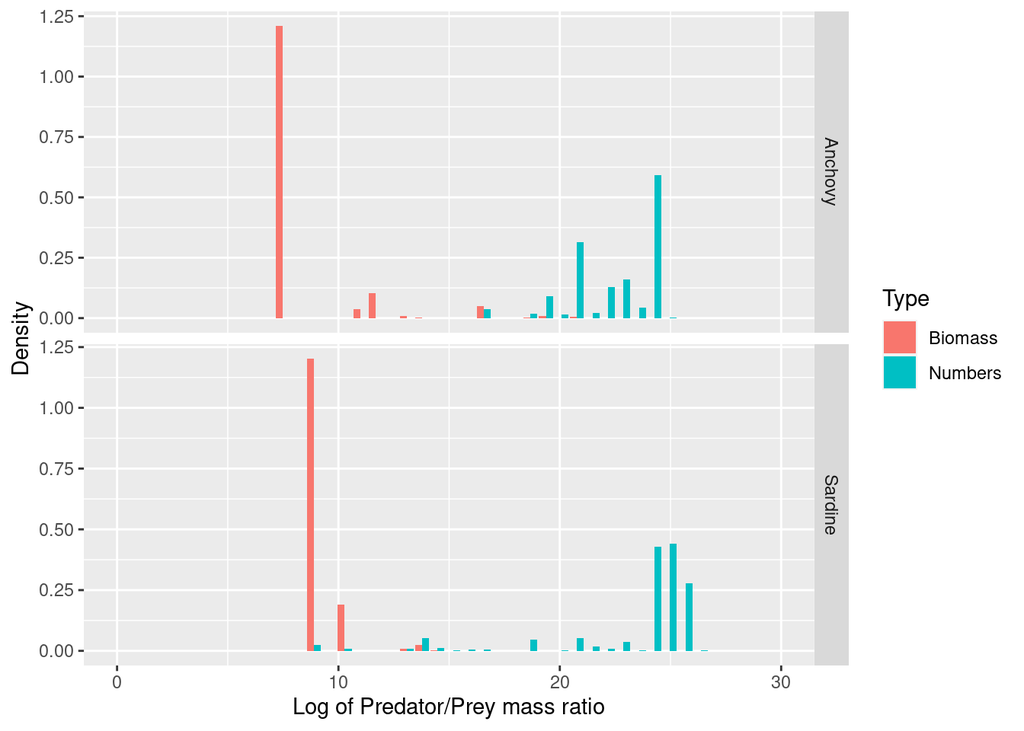

```r
binned_stomach %>%
  ggplot(aes(l, Density, fill = Type)) +
    geom_col(position = "dodge") +
    facet_grid(rows = vars(Species), scales = "free_y") +
    xlab("Log of Predator/Prey mass ratio") +
    expand_limits(x = c(0, 30))
```

Note how the biomass of prey is concentrated at very different predator/prey mass ratios than the number of prey. The information about the biomass distribution is contained mostly in the left tail of the number density and, vice versa, the information about the number distribution is mostly contained in the right tail of the biomass density.

### Kernel density estimation

An alternative way to estimate densities from data is provided by the kernel density estimation method. Here, rather than aggregating observations in bins, each observation contributes its own little Gaussian centred at that data value. The estimated density function is obtained by summing all these little Gaussians together. That produces a smoother estimate than the histogram method. The width of the individual Gaussians plays the same role as the bins size. There are some heuristics that allow R to choose a sensible width that provides a good summary of the data. We decrease that bandwidth by a factor of 1/2 to get a slightly more detailed view:

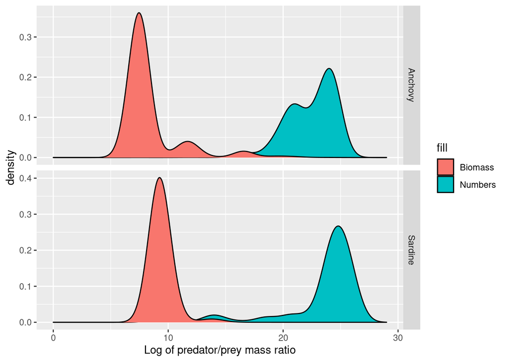

```r
adjust <- 1/2  # decrease bandwidth for kernel estimate
stomach <- stomach %>%
    group_by(Species) %>%
    mutate(weight_numbers = Nprey / sum(Nprey),
           weight_biomass = Nprey * wprey / sum(Nprey * wprey))
ggplot(stomach) +
    geom_density(aes(l, weight = weight_numbers,
                     fill = "Numbers"),
                 adjust = adjust) +
    geom_density(aes(l, weight = weight_biomass,
                     fill = "Biomass"),
                 adjust = adjust) +
    facet_grid(rows = vars(Species), scales = "free_y") +
    xlab("Log of predator/prey mass ratio") +
    expand_limits(x = c(0, 29))
```

This idea of spreading out each observation into a little Gaussian is particularly appropriate for this dataset, where the size of the observed prey item is only estimated from the species identity of the prey item and where also the predator size is not know exactly. Both of these lead to uncertainty in the predator/prey size ratio.

### Gaussian does not fit

Let us start by observing that it would be very inappropriate to use a Gaussian curve to describe these densities. We illustrate this in the case of the Anchovy. We plot the normal distribution with the same mean and standard deviation as the data on top of the histogram for the number distribution.

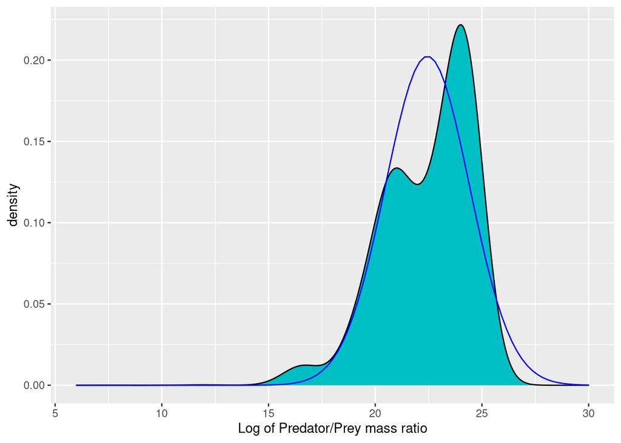

```r
chosen_species = "Anchovy"
weighted.sd <- function(x, w) {
  sqrt(sum(w * (x - weighted.mean(x, w))^2))
}
fit <- stomach %>%
  filter(Species == chosen_species) %>%
  summarise(mean = weighted.mean(l, weight_numbers),
            sd = weighted.sd(l, weight_numbers))
stomach %>%
  filter(Species == chosen_species) %>%
  ggplot() +
    geom_density(aes(l, weight = weight_numbers),
                 fill = "#00BFC4", adjust = adjust) +
    xlab("Log of Predator/Prey mass ratio") +
    stat_function(fun = dnorm,
                  args = list(mean = fit$mean,
                              sd = fit$sd),
                  colour = "blue") +
    expand_limits(x = c(6, 30))
```

This may not look so bad. However, if the size distribution was correctly described by the normal distribution, i.e., if
$$f_l(l) \propto \exp\left(-\frac{(l-\mu)^2}
{2\sigma^2}\right),$$
then the biomass density would be given by
$$\begin{split}
b_l(l) &\propto e^{-l}f_l(l)
\propto \exp\left(-\frac{(l-\mu)^2}
{2\sigma^2} - l\right)\\
&\propto \exp\left(-\frac{(l-(\mu-\sigma^2)^2}
{2\sigma^2}\right)
\end{split}$$
Thus the biomass would also be normally distributed with the mean shifted by $\sigma^2$. Putting this into the same picture gives

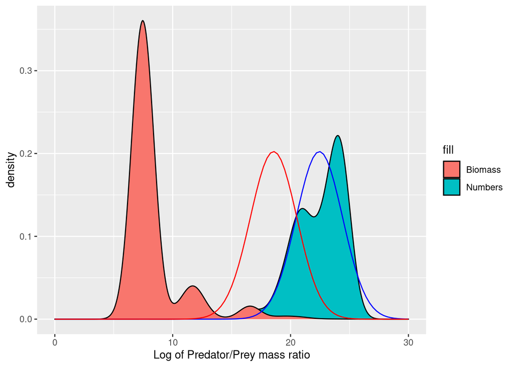

```r
stomach %>%
  filter(Species == chosen_species) %>%
  ggplot() +
    geom_density(aes(l, weight = weight_numbers,
                     fill = "Numbers"),
                 adjust = adjust) +
    geom_density(aes(l, weight = weight_biomass,
                     fill = "Biomass"),
                 adjust = adjust) +
    xlab("Log of Predator/Prey mass ratio") +
    stat_function(fun = dnorm,
                  args = list(mean = fit$mean,
                              sd = fit$sd),
                  colour = "blue") +
    stat_function(fun = dnorm,
                  args = list(mean = fit$mean - fit$sd^2,
                              sd = fit$sd),
                  colour = "red") +
    expand_limits(x = c(0, 30))
```

This does not fit the actual biomass distribution at all!

For the Sardine the normal distribution fits neither the number density nor the biomass density.

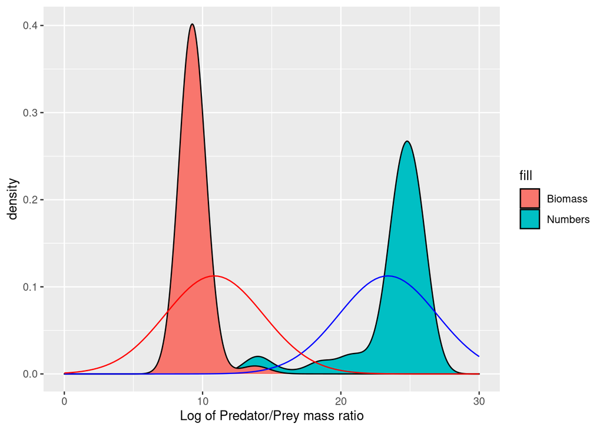

```r
chosen_species = "Sardine"
weighted.sd <- function(x, w) {
  sqrt(sum(w * (x - weighted.mean(x, w))^2))
}
fit <- stomach %>%
  filter(Species == chosen_species) %>%
  summarise(mean = weighted.mean(l, weight_numbers),
            sd = weighted.sd(l, weight_numbers))
stomach %>%
  filter(Species == chosen_species) %>%
  ggplot() +
    geom_density(aes(l, weight = weight_numbers,
                     fill = "Numbers"),
                 adjust = adjust) +
    geom_density(aes(l, weight = weight_biomass,
                     fill = "Biomass"),
                 adjust = adjust) +
    xlab("Log of Predator/Prey mass ratio") +
    stat_function(fun = dnorm,
                  args = list(mean = fit$mean,
                              sd = fit$sd),
                  colour = "blue") +
    stat_function(fun = dnorm,
                  args = list(mean = fit$mean - fit$sd^2,
                              sd = fit$sd),
                  colour = "red") +
    expand_limits(x = c(0, 30))
```

### Exponential fits better

We have learned above that the small number of large individuals in the stomach provide the dominant contribution to the biomass consumed by the predator and hence are important. To make them more visible, we show the histograms again but now with a logarithmic y-axis

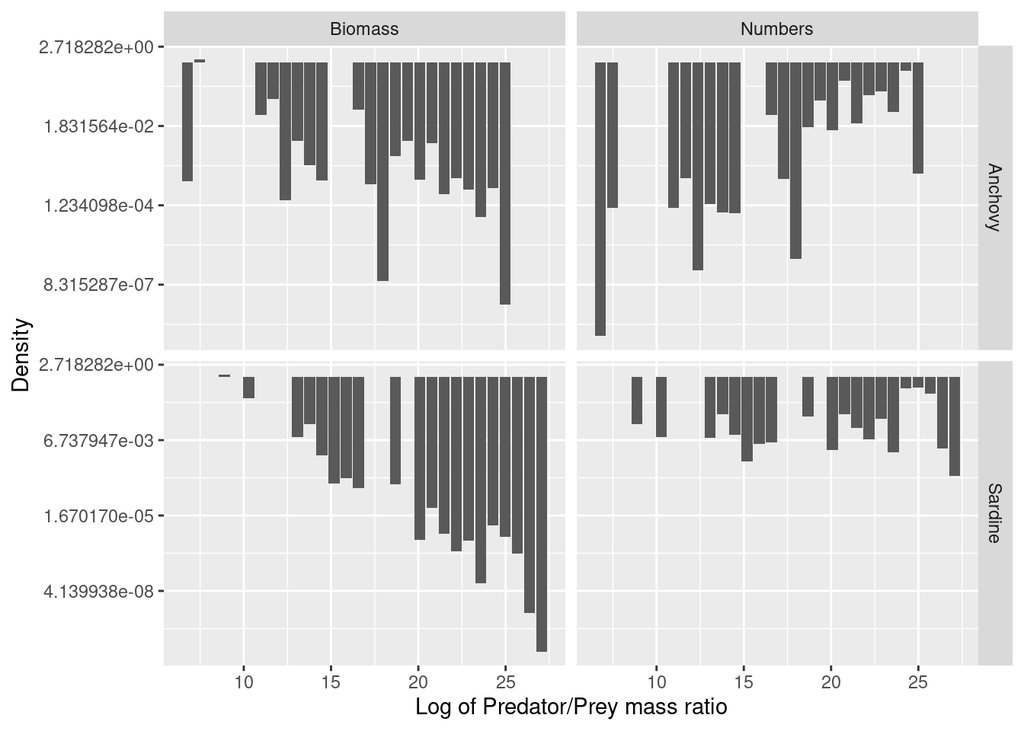

```r
binned_stomach %>%
  ggplot(aes(l, Density)) +
    geom_col() +
    facet_grid(Species ~ Type, scales = "free_y") +
    xlab("Log of Predator/Prey mass ratio") +
    scale_y_continuous(trans = "log")
```

This motivates us to try to fit a truncated exponential distribution to the data (which would be a truncated power-law distribution when working with the predator/prey mass ratio instead of its logarithm).

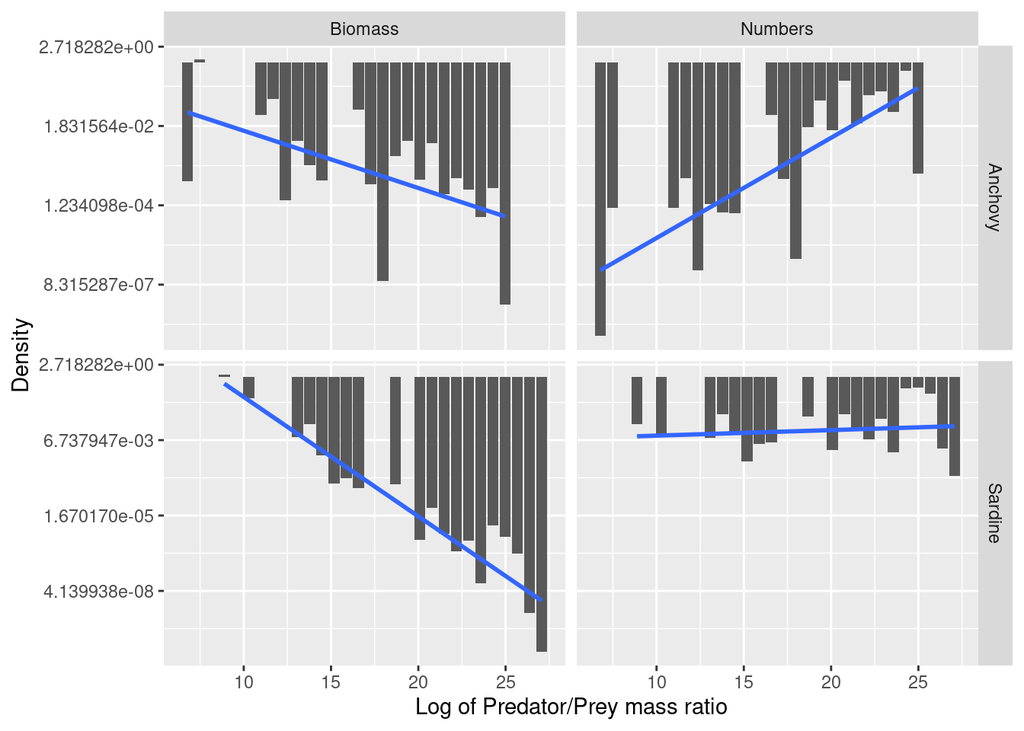

```r
binned_stomach %>%
  ggplot(aes(l, Density)) +
    geom_col() +
    geom_smooth(method = "lm", se = FALSE) +
    facet_grid(Species ~ Type, scales = "free_y") +
    xlab("Log of Predator/Prey mass ratio") +
    scale_y_continuous(trans = "log")
```

Of course again we have the problem that the biomass density is not independent of the number density, so fitting separate distributions to the two is not appropriate. If we assume that the number distribution follows the exponential distribution, i.e.,
$$f_l(l)\propto \exp(\alpha\ l)$$
for some parameter $\alpha$ then the biomass distribution follows an exponential distribution with parameter $\alpha - 1$:
$$b_l(l) = e^{-l}f_l(l)
\propto \exp((\alpha - 1)l).$$
Amazingly, the parameters of the independently fitted distributions do almost perfectly have this relationship:

```r
binned_stomach %>%
  group_by(Species, Type) %>%
  group_modify(~ broom::tidy(lm(log(Density) ~ l, data = .x))) %>%
  filter(term == "l")
```

```
## # A tibble: 4 x 7
## # Groups:   Species, Type [4]
##   Species Type    term  estimate std.error statistic  p.value
##   <chr>   <chr>   <chr>    <dbl>     <dbl>     <dbl>    <dbl>
## 1 Anchovy Biomass l      -0.361     0.124     -2.92  8.82e- 3
## 2 Anchovy Numbers l       0.632     0.120      5.24  4.62e- 5
## 3 Sardine Biomass l      -0.950     0.0798   -11.9   5.75e-10
## 4 Sardine Numbers l       0.0441    0.0803     0.549 5.90e- 1
```

The parameter of the biomass distribution is almost exactly 1 less than the parameter of the numbers distribution.

### Maximum likelihood fit

Fitting the exponential distribution by fitting a linear model to the logged histogram is not really appropriate. A better method would be to fit directly to the data using the maximum likelihood principle.

#### Number distribution

The density of the truncated exponential distribution is
$$f_l(l) = \begin{cases}
\frac{1}{Z}\exp(\alpha\ l) &\text{ if }l\in[l_{min}, l_{max}]\\
0 &\text{ otherwise,}
\end{cases}$$
where
$$Z = \int_{l_{min}}^{l_{max}}\exp(\alpha\ l)dl=
\frac{1}{\alpha}\left(\exp(\alpha\ l_{max})-\exp(\alpha\ l_{min})\right).$$

Due to the way the parameters $l_{min}$ and $l_{max}$ enter in the normalisation of the probability density, the maximum likelihood will be attained at the largest possible value for $l_{min}$ and the smallest possible value for $l_{max}$, i.e., they are determined by the smallest and largest value appearing in the dataset.

It remains only to estimate the rate parameter $\alpha$. The log likelihood function is
$$\begin{split}
l(\alpha) &= \sum_i\left(\alpha\ l_i
- \log\left(\frac{1}{\alpha}\left(\exp(\alpha\ l_{max})-\exp(\alpha\ l_{min})\right)\right)\right)\\
&=\alpha \sum_il_i + n\log|\alpha|
- n\log\left|\exp(\alpha\ l_{max})-\exp(\alpha\ l_{min})\right|
\end{split}$$

In order to avoid having to minimize this numerically, we now make the approximation that $\alpha$ is large enough so that $\exp(\alpha\ l_{min})$ is negligibly small compared to $\exp(\alpha\ l_{max})$. Then
$$l(\alpha)\approx\alpha \sum_il_i + n\log(\alpha)
- n\ \alpha\ l_{max}$$
To find the value of $\alpha$ that maximizes this likelihood we set
$$0=\frac{dl(\alpha)}{d\alpha} \approx \sum_il_i+\frac{n}{\alpha}-n\ l_{max}$$
and solve for $\alpha$. This gives
$$\alpha \approx \frac{1}{l_{max}-\bar{l}}$$
where $\bar{l}$ is the average over all $l_i$.

```r
est <- stomach %>%
  group_by(Species) %>%
  summarise(lbar = weighted.mean(l, weight_numbers),
            lmax = max(l),
            lmin = min(l),
            alpha = 1/(lmax - lbar))
est
```

```
## # A tibble: 2 x 5
##   Species  lbar  lmax  lmin alpha
##   <chr>   <dbl> <dbl> <dbl> <dbl>
## 1 Anchovy  22.4  25.3  6.78 0.350
## 2 Sardine  23.4  27.1  9.07 0.273
```

Note how sensitive these estimates are to the value of `lmax`. To see why these are not good estimates, let us have a look what the fit looks like.

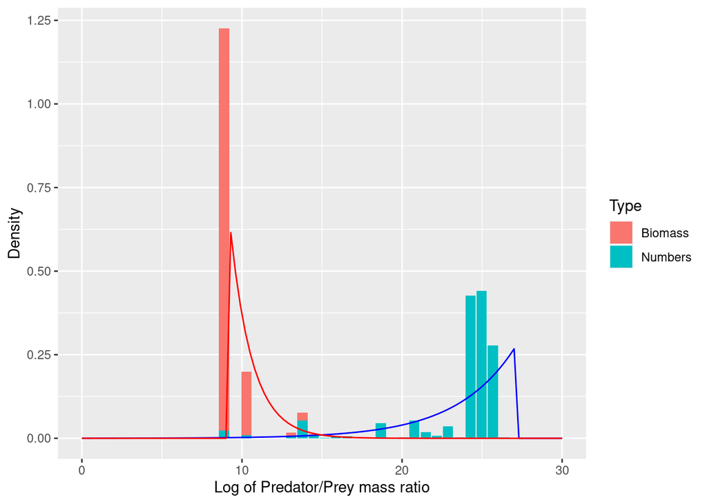

```r
dnumbers <- function(l, alpha, lmax) {
  d <- as.numeric(l <= lmax)
  d[d > 0] <- dexp(lmax - l[d > 0], alpha)
  return(d)
}
dbiomass <- function(l, alpha, lmin) {
  d <- as.numeric(l >= lmin)
  d[d > 0] <- dexp(l[d > 0] - lmin, 1 - alpha)
  return(d)
}
selected_species <- "Sardine"
binned_stomach %>%
  filter(Species == selected_species) %>%
  ggplot() +
    geom_col(aes(l, Density, fill = Type)) +
    stat_function(fun = dnumbers,
                  args = list(alpha = est$alpha[est$Species == selected_species],
                              lmax = est$lmax[est$Species == selected_species]),
                  colour = "blue") +
    stat_function(fun = dbiomass,
                  args = list(alpha = est$alpha[est$Species == selected_species],
                              lmin = est$lmin[est$Species == selected_species]),
                  colour = "red") +
    xlab("Log of Predator/Prey mass ratio")  +
    expand_limits(x = c(0, 30))
```

Clearly the density should not rise exponentiall all the way to the largest observed value `lmax` but there should be a smoother cutoff. There should also be a smoother cutoff at `lmin`.

#### Biomass distribution

If $f_l(l)$ is given by the truncated exponential distribution with rate parameter $\alpha$ then the biomass distribution $b_l(l)$ is given by the truncated exponential distribution with rate parameter $\alpha_B = \alpha - 1$. If this is negative enough that $\exp(\alpha_B\ l_{max})$ is negligibly small compared to $\exp(\alpha_B\ l_{min})$, then
$$l(\alpha_B)\approx\alpha_B \sum_iw_il_i
+ \sum_iw_i\left(\log(-\alpha_B)
- \alpha_B\ l_{min}\right)$$
To find the value of $\alpha$ that maximizes this likelihood we set
$$0=\frac{dl(\alpha_B)}{d\alpha_B} \approx \sum_iw_il_i
+\sum_iw_i\left(\frac{1}{\alpha_B}-\ l_{min}\right)$$
and solve for $\alpha_B$. This gives
$$\alpha_B \approx \frac{1}{l_{min} - \bar{l}_w}$$
where $\bar{l}_w$ is the weighted mean
$$\bar{l}_w = \frac{\sum_iw_il_w}{\sum_iw_i}.$$

```r
est2 <- stomach %>%
  group_by(Species) %>%
  summarise(lbar = weighted.mean(l, weight_numbers),
            lmax = max(l),
            lmin = min(l),
            alpha = 1/(lmax - lbar),
            lbarw = weighted.mean(l, weight_biomass),
            alpha_B = 1 / (lmin - lbarw),
            diff = alpha - alpha_B
            )
est2 %>% select(Species, alpha, alpha_B, diff)
```

```
## # A tibble: 2 x 4
##   Species alpha alpha_B  diff
##   <chr>   <dbl>   <dbl> <dbl>
## 1 Anchovy 0.350  -0.622 0.973
## 2 Sardine 0.273  -3.13  3.40
```

The difference between $\alpha$ and $\alpha_B$ should be 1. This works quite well for anchovy, but fails dramatically for sardine. The failure is not surprising: the estimate for $\alpha_B$ depends sensitively on $l_{min}$, which the maximum likelihood principle told us to choose to be equal to the smallest observed $l_i$. However, due to the small number of observations with small values for $l$, it may well be that the true smallest value for $l$ is smaller than the smallest observed and has simply by chance not been detected.

A natural question to ask therefore is if with a different choice for $l_{min}$ the estimate for $\alpha_B$ would agree with our estimate for $\alpha - 1$. So we set $\alpha_B = \alpha - 1$ and solve for $l_{min}$:
$$l_{min} = \bar{l}_w + \frac{1}{\alpha - 1}$$

```r
est3 <- stomach %>%
  group_by(Species) %>%
  summarise(lbar = weighted.mean(l, weight_numbers),
            lmax = max(l),
            lmin = min(l),
            alpha = 1/(lmax - lbar),
            lbarw = weighted.mean(l, weight_biomass),
            lmin_B = lbarw + 1 / (alpha - 1),
            diff = lmin - lmin_B
            )
est3 %>% select(Species, lmin, lmin_B, diff)
```

```
## # A tibble: 2 x 4
##   Species  lmin lmin_B    diff
##   <chr>   <dbl>  <dbl>   <dbl>
## 1 Anchovy  6.78   6.85 -0.0671
## 2 Sardine  9.07   8.02  1.06
```

So the number distribution and the biomass distribution would be consistent with each other if the actual $l_{min}$ for sardine was just a little bit smaller than the smallest observed one. This is not unreasonable.

### Sigmoidal cutoffs

The simplest way to implement smoother cutoffs at the ends of the distributions is to multiply by two sigmoidal functions: a rising one centred near `lmin` and a falling one near `lmax`. So we choose
$$f_l(l) \propto \frac{\exp(\alpha\ l)}
{\left(1+e^{u_l(l_l - l)}\right)
\left(1+e^{u_r(l - l_r)}\right)}.$$

```r
fl <- function(l, alpha, ll, ul, lr, ur) {
  exp(alpha * l) /
    (1 + exp(ul * (ll - l))) /
    (1 + exp(ur * (l - lr)))
}
dtexp <- function(l, alpha, ll, ul, lr, ur) {
  d <- fl(l, alpha, ll, ul, lr, ur) /
    integrate(fl, 0, 30, alpha = alpha,
              ll = ll, ul = ul, lr = lr, ur = ur)$value
  if (any(d <= 0)) {
    stop("The density contains non-positive values when",
         " alpha = ", alpha, " ll = ", ll, " ul = ", ul,
         " lr = ", lr, " ur = ", ur)
  }
  return(d)
}
```

We have introduced 4 new parameters into the distribution: $l_l$ is the log of the predator/prey mass ratio around which the sigmoidal switch-on happens and $u_l$ determines the steepness of that switch-on. Similarly $l_r$ is the log of the predator/prey mass ratio around which the sigmoidal switch-off happens and $u_r$ determines the steepness of that switch-off. Here is the plot of an example with switch-on around $l = 5$ and switch-off around $l = 25$.

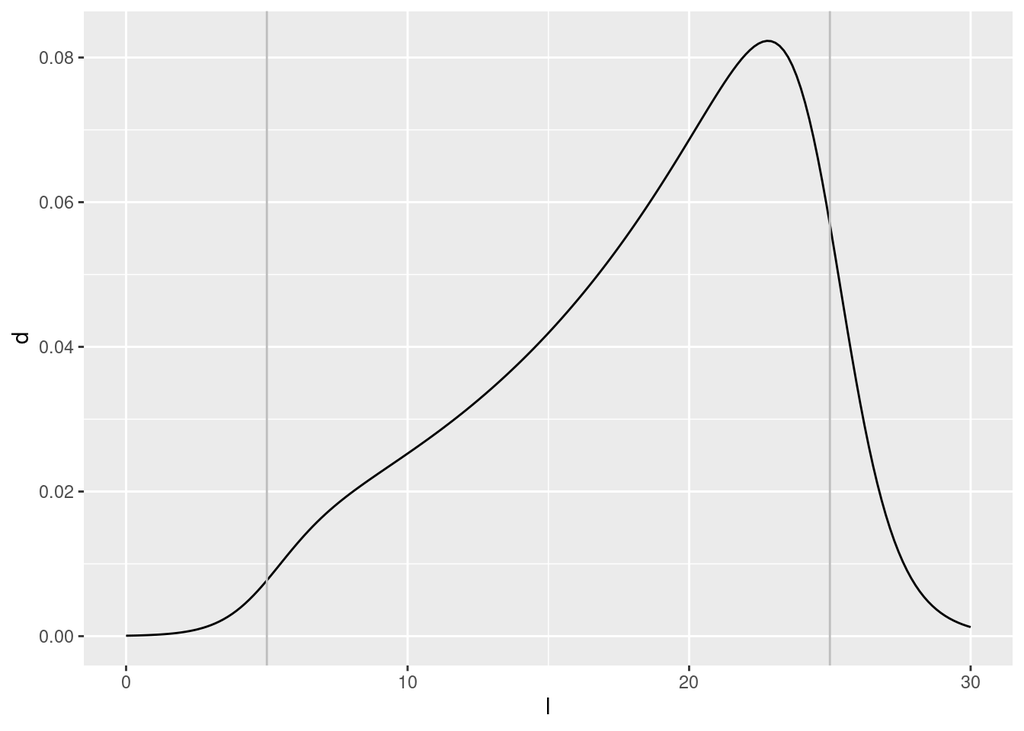

```r
df <- tibble(
  l = seq(0, 30, length.out = 200),
  d = dtexp(l, 0.1, 5, 1, 25, 1)
)
ggplot(df) +
  geom_line(aes(l, d)) +
  geom_vline(xintercept = 5, colour = "grey") +
  geom_vline(xintercept = 25, colour = "grey")
```

The probability density $f_r(r)$ of the predator/prey mass ratio $r=e^l$ is then a power-law distribution with exponent $\alpha - 1$ and sigmoidal cut-offs:
$$f_r(r) \propto e^{-l}f_l(l)
= \frac{r^{\alpha - 1}}
{\left(1+\left(\frac{e^{l_l}}{r}\right)^{u_l}\right)
\left(1+\left(\frac{r}{e^{l_r}}\right)^{u_r}\right)}.$$

#### Maximum likelihood fit

We estimate the 5 parameters by maximum likelihood estimation, which in this case can only be done numerically.

```r
mle_texp <- function(df) {
  loglik <- function(alpha, ll, ul, lr, ur) {
    L <- dtexp(df$l, alpha, ll, ul, lr, ur)
    - sum(log(L) * df$weight_numbers)
  }
  mle2(loglik, start = list(
    alpha = 0.5,
    ll = min(df$l),
    lr = max(df$l),
    ul = 5,
    ur = 5))
}
est <- stomach %>%
  group_modify(~ broom::tidy(mle_texp(.x))) %>%
  select(Species, term, estimate) %>%
  spread(term, estimate)
est
```

```
## # A tibble: 2 x 6
## # Groups:   Species [2]
##   Species alpha    ll    lr    ul    ur
##   <chr>   <dbl> <dbl> <dbl> <dbl> <dbl>
## 1 Anchovy 0.535  7.05  24.3  5.10  56.8
## 2 Sardine 0.391  7.85  26.0  5.41  26.3
```

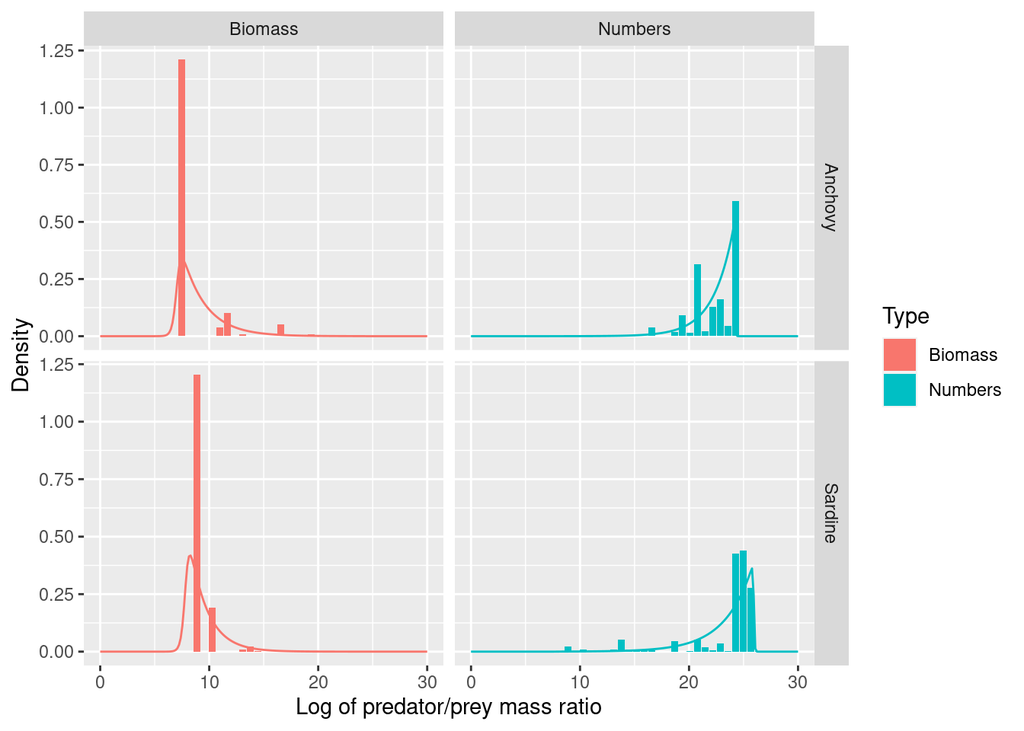

```r
grid = seq(0, 30, length.out = 200)
texpdens <- plyr::ddply(est, "Species", function(df) {
  data.frame(
    l = grid,
    Numbers = dtexp(grid, df$alpha, df$ll, df$ul, df$lr, df$ur),
    Biomass = dtexp(grid, df$alpha - 1, df$ll, df$ul, df$lr, df$ur)
  )}) %>%
  gather(Type, Density, Numbers, Biomass)

ggplot(binned_stomach) +
  geom_col(aes(l, Density, fill = Type)) +
  facet_grid(Species ~ Type, scales = "free_y") +
    xlab("Log of predator/prey mass ratio") +
    geom_line(aes(l, Density, colour = Type), data = texpdens)
```

## Feeding kernel

Now we will discuss how the stomach content is related to the feeding kernel.

The stomach content is the result of a balance between the rate at which prey items are ingested and the rate at which they are digested. So we start by looking at ingestion and digestion rates.

### Ingestion

The rate of ingestion $I(w|w')$ is proportional to the product of the feeding kernel $\phi(w'/w)$ and the prey number density $N_c(w)$:
$$I(w|w') = i(w') \phi(w'/w)\ N_c(w)$$
The proportionality constant $i(w')$ only depends on the predator size $w'$ and, as we will see, we will not need it in our analysis. The prey number density $N_c(w)$ is defined as usual such that $N_c(w)dw$ is the total number of potential prey items with sizes between $w$ and $w+dw$.

In a multi-species model in which the predator has different interaction strengths with different prey species, given by an interaction matrix $\theta_{ij}$, the prey number density for a predator of species $i$ would be obtained from the number densities $N_j(w)$ of individual prey species as
$$N_c(w) = \sum_j \theta_{ij}N_j(w).$$
Of course, we do not know the prey density that the predators experienced that were sampled in the stomach observation. So the best we can do is to assume that it was reasonably close to the Sheldon spectrum
$$N_c(w) = n\ w^{-\lambda}$$
with $\lambda \approx 2$.

### Digestion

Prey items will stay identifiable in the predator stomach only for a certain period of time before they disintegrate. After that time they will not contribute to the observation of prey items in the stomach. Of course we do not know in detail the rate at which prey items are digested. However it is reasonable to make the approximation that the rate at which a prey item has its bodymass digested away scales with body size as $w^{2/3}$ because digestion acts on the surface of the prey item and this surface scales approximately as $w^{2/3}$. Let us assume that a prey item becomes unidentifiable when a fixed percentage of its body mass is digested. The time until that has happened is proportional to the body mass divided by the rate at which mass is digested: $T\propto w/w^{2/3} = w^{1/3}$. The rate at which a prey item of size $w$ disintegrate is equal to the inverse of the disintegration time. Denoting that rate by $D(w)$ we have
$$D(w) = d\ w^{-1/3}.$$
The proportionality constant $d$ will not be important in what follows.

### Balance equation

We describe the size distribution of prey in stomachs of predators of size $w'$ by the density function $N_w(w|w')$.

The observed stomach content is such that the rate at which prey items of a particular size are ingested is equal to the rate at which such items disintegrates due to digestion, $I(w|w') = D(w)N_w(w|w')$. Using our expressions for these rates we obtain
$$i(w') \phi(w'/w)\ n\ w^{-\lambda} = d\ w^{-1/3} N_w(w|w').$$
This we can solve for the feeding kernel:
$$\phi(w'/w) = \frac{d}{i(w')\,n}\ w^{\lambda - 1/3}N_w(w|w').$$
Using further that
$$N_w(w|w') \propto e^lf_l(l)$$
where $l=\log(w'/w)$ we find
$$\phi(w'/w) \propto e^{(4/3 - \lambda)l}f_l(l)$$
This tells us that if the stomach distribution $f_l(l)$ is described by the truncated exponential distribution with rate $\alpha$, the feeding kernel as a function of $l$ is described by the truncated exponential distribution with rate $\alpha + 4/3 - \lambda$.

```r
est %>%
  mutate(exp = alpha + 4/3 - 2.05)
```

```
## # A tibble: 2 x 7
## # Groups:   Species [2]
##   Species alpha    ll    lr    ul    ur    exp
##   <chr>   <dbl> <dbl> <dbl> <dbl> <dbl>  <dbl>
## 1 Anchovy 0.535  7.05  24.3  5.10  56.8 -0.181
## 2 Sardine 0.391  7.85  26.0  5.41  26.3 -0.326
```

If the stomach distribution $f_l(l)$ is the normal distribution with mean $\mu$ and variance $\sigma^2$ then the feeding kernel as a function of $l$ is also a Gaussian with the same variance and with mean $\mu + (4/3 - \lambda)\sigma^2$.

## Barnes dataset

Reading in the data

```r
stomach_full <-
    read_tsv("Predator_and_prey_body_sizes_in_marine_food.csv",
             na = c("", "n/a"),
             guess_max = 10000)
stomach_full
```

```
## # A tibble: 34,931 x 60
##    `Record number` `In-ref ID` `Individual ID` Predator       `Predator common …
##              <dbl> <chr>                 <dbl> <chr>          <chr>
##  1               1 ATSH063                   1 Rhizoprionodo… Atlantic sharpnos…
##  2               2 ATSH080                   2 Rhizoprionodo… Atlantic sharpnos…
##  3               3 ATSH089                   3 Rhizoprionodo… Atlantic sharpnos…
##  4               4 ATSH143                   4 Rhizoprionodo… Atlantic sharpnos…
##  5               5 ATSH161                   5 Rhizoprionodo… Atlantic sharpnos…
##  6               6 ATSH166                   6 Rhizoprionodo… Atlantic sharpnos…
##  7               7 ATSH172                   7 Rhizoprionodo… Atlantic sharpnos…
##  8               8 ATSH192                   8 Rhizoprionodo… Atlantic sharpnos…
##  9               9 ATSH205                   9 Rhizoprionodo… Atlantic sharpnos…
## 10              10 ATSH205                   9 Rhizoprionodo… Atlantic sharpnos…
## # … with 34,921 more rows, and 55 more variables: Predator  taxon <chr>,
## #   Predator lifestage <chr>, Type of feeding interaction <chr>,
## #   Predator length <dbl>, Predator length unit <chr>,
## #   Predator dimension measured <chr>, Predator standard length <dbl>,
## #   Predator fork length <dbl>, Predator total length <dbl>,
## #   Predator TL/FL/SL conversion reference <chr>,
## #   Standardised predator length <dbl>, Predator measurement type <chr>,
## #   Predator length-mass conversion method <chr>,
## #   Predator length-mass conversion reference <chr>,
## #   Predator quality of length-mass conversion <dbl>, Predator mass <dbl>,
## #   Predator mass unit <chr>, Predator mass check <dbl>,
## #   Predator mass check diff <dbl>, Predator ratio mass/mass <dbl>,
## #   SI predator mass <dbl>, Diet coverage <chr>, Prey <chr>,
## #   Prey common name <chr>, Prey taxon <chr>, Prey length <dbl>,
## #   Prey length unit <chr>, Prey conversion to length method <chr>,
## #   Prey quality of conversion to length <dbl>,
## #   Prey conversion to length reference <chr>, SI prey length <dbl>,
## #   Prey dimension measured <chr>, Prey width <dbl>, Prey width unit <chr>,
## #   Prey measurement type <chr>, Prey mass <dbl>, Prey mass unit <chr>,
## #   Prey mass check <dbl>, Prey mass check diff <dbl>,
## #   Prey ratio mass/mass <dbl>, SI prey mass <dbl>,
## #   Prey conversion to mass method <chr>,
## #   Prey conversion to mass reference <chr>,
## #   Prey quality of conversion to mass <dbl>, Geographic location <chr>,
## #   Latitude <chr>, Longitude <chr>, Depth <dbl>, Mean annual temp <dbl>,
## #   SD annual temp <dbl>, Mean PP <dbl>, SD PP <dbl>, Reference <chr>,
## #   Specific habitat <chr>, Notes / assumptions <chr>
```

We select only the relevant columns and remove predator species with fewer than 1000 observations.

```r
stomach <- stomach_full %>%
    select(Species = `Predator common name`,
           wpredator = `SI predator mass`,
           wprey = `SI prey mass`) %>%
    group_by(Species) %>%
    filter(n() > 1000) %>%
    mutate(Nprey = 1,
           l = log(wpredator / wprey),
           weight_numbers = Nprey / sum(Nprey),
           weight_biomass = Nprey * wprey / sum(Nprey * wprey))
stomach
```

```
## # A tibble: 23,169 x 7
## # Groups:   Species [12]
##    Species             wpredator wprey Nprey     l weight_numbers weight_biomass
##    <chr>                   <dbl> <dbl> <dbl> <dbl>          <dbl>          <dbl>
##  1 Atlantic bluefin t…     61666  3.51     1  9.77       0.000524      0.0000285
##  2 Atlantic bluefin t…     61666  3.51     1  9.77       0.000524      0.0000285
##  3 Atlantic bluefin t…     61666  3.51     1  9.77       0.000524      0.0000285
##  4 Atlantic bluefin t…     61666  4.63     1  9.50       0.000524      0.0000376
##  5 Atlantic bluefin t…     61666  4.63     1  9.50       0.000524      0.0000376
##  6 Atlantic bluefin t…     61666  4.63     1  9.50       0.000524      0.0000376
##  7 Atlantic bluefin t…     61666  4.63     1  9.50       0.000524      0.0000376
##  8 Atlantic bluefin t…     61666  4.63     1  9.50       0.000524      0.0000376
##  9 Atlantic bluefin t…     61666  4.63     1  9.50       0.000524      0.0000376
## 10 Atlantic bluefin t…     61666  5.97     1  9.24       0.000524      0.0000485
## # … with 23,159 more rows
```

This leaves

```r
unique(stomach$Species)
```

```
##  [1] "Atlantic bluefin tuna"   "Atlantic cod"
##  [3] "Yellowfin tuna"          "Bigeye tuna"
##  [5] "Silver hake"             "Bluefish"
##  [7] "Albacore"                "Winter skate"
##  [9] "Spurdog / spiny dogfish" "Smooth dogfish"
## [11] "Antarctic fish"          "European sea bass"
```

For later purposes we also bin the observations.

```r
no_bins <- 30  # Number of bins
binsize <- (max(stomach$l) - min(stomach$l)) / (no_bins - 1)
breaks <- seq(min(stomach$l) - binsize/2,
              by = binsize, length.out = no_bins + 1)
binned_stomach <- stomach %>%
    # bin data
    mutate(cut = cut(l, breaks = breaks, right = FALSE,
                     labels = FALSE)) %>%
    group_by(Species, cut) %>%
    summarise(Numbers = sum(Nprey),
              Biomass = sum(Nprey * wprey)) %>%
    # normalise
    mutate(Numbers = Numbers / sum(Numbers) / binsize,
           Biomass = Biomass / sum(Biomass) / binsize)  %>%
    # column for predator/prey size ratio
    mutate(l = map_dbl(cut, function(idx) breaks[idx] + binsize/2)) %>%
    gather(key = "Type", value = "Density", Numbers, Biomass)
```

We take a look at the hexplots to see that the assumption that the log predator/prey mass ratio is independent of the predator size is not unreasonable.

[output not shown]

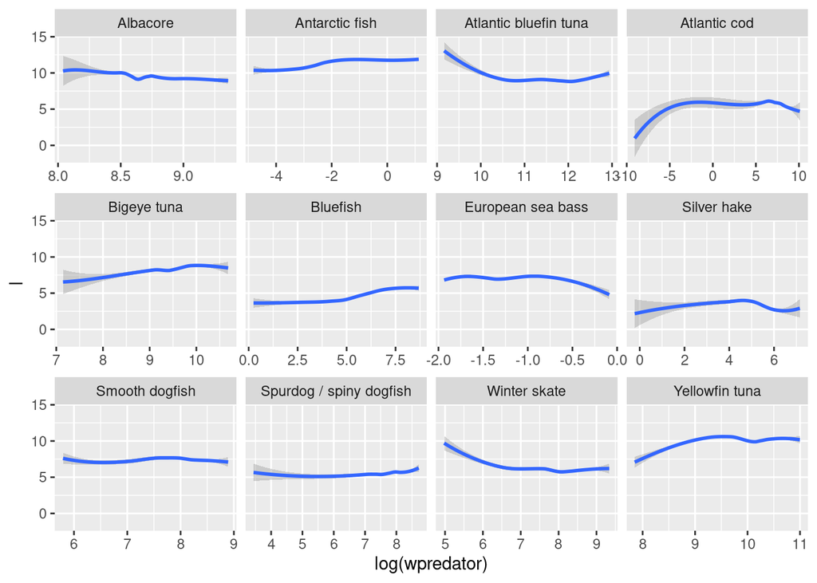

```r
stomach %>% ggplot(aes(log(wpredator), l)) +
    geom_hex(bins = 15) +
    scale_fill_viridis_c(trans = "log", breaks = c(2, 10, 50, 250, 1250)) +
    stat_smooth(method = 'loess') +
    facet_wrap(~Species, scales = "free_x")
```

I think it is fair to say that these plots do not exhibit any systematic trend.

### Gaussian sometimes fits

Next we fit normal densities:

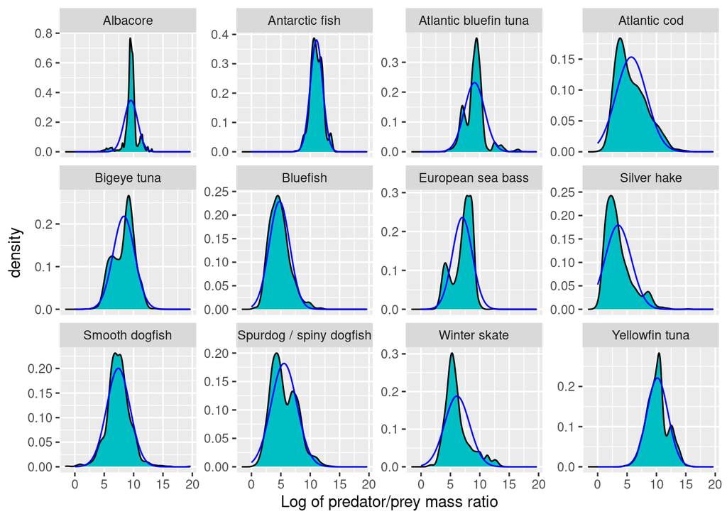

```r
grid <- seq(0, max(stomach$l), length = 100)
normaldens <- plyr::ddply(stomach, "Species", function(df) {
  data.frame(
    l = grid,
    density = dnorm(grid, mean(df$l), sd(df$l))
  )
})

ggplot(stomach) +
    geom_density(aes(l, weight = weight_numbers), fill = "#00BFC4") +
    facet_wrap(~Species, scales = "free_y", ncol = 4) +
    xlab("Log of predator/prey mass ratio")  +
    geom_line(aes(l, density), data = normaldens,
                  colour = "blue")
```

This does not look too bad at first sight. However we now know to also look at the biomass distribution. We plot the normal density arising from the above fits on top of the observed biomass distribution.

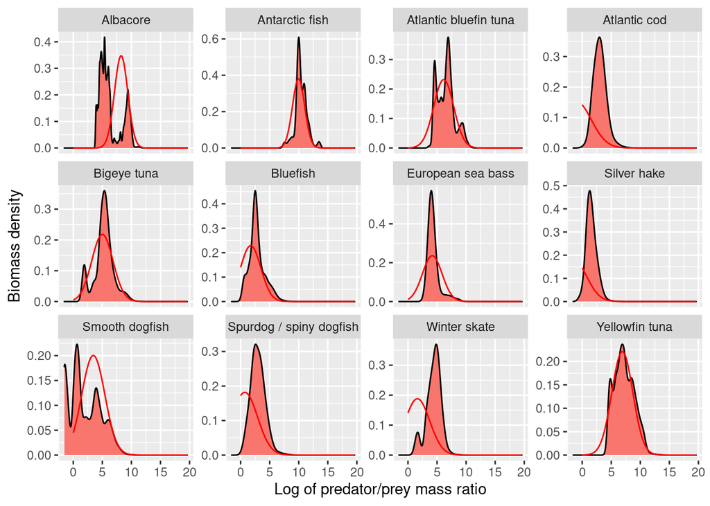

```r
grid <- seq(0, max(stomach$l), length = 100)
shifted_normaldens <- plyr::ddply(stomach, "Species", function(df) {
  data.frame(
    l = grid,
    density = dnorm(grid, mean(df$l) - sd(df$l)^2, sd(df$l))
  )
})

ggplot(stomach) +
    geom_density(aes(l, weight = weight_biomass), fill = "#F8766D") +
    facet_wrap(~Species, scales = "free_y", ncol = 4) +
    xlab("Log of predator/prey mass ratio") +
    ylab("Biomass density") +
    geom_line(aes(l, density), data = shifted_normaldens,
                  colour = "red")
```

This looks o.k. for some species, but is totally wrong for others, in particular the atlantic cod and the silver hake, where the normal distribution incorrectly predicts most of the biomass to be at sizes larger than the predator size (negative log of predator/prey mass ratio).

### Truncated exponential

```r
mle_texp <- function(df) {
  loglik <- function(alpha, ll, ul, lr, ur) {
    L <- dtexp(df$l, alpha, ll, ul, lr, ur)
    - sum(log(L) * df$weight_numbers)
  }
  mle2(loglik, start = list(
    alpha = 0.5,
    ll = min(df$l),
    lr = max(df$l),
    ul = 5,
    ur = 5))
}
est <- stomach %>%
  group_modify(~ broom::tidy(mle_texp(.x))) %>%
  select(Species, term, estimate) %>%
  spread(term, estimate)
est
```

```
## # A tibble: 12 x 6
## # Groups:   Species [12]
##    Species                  alpha    ll    lr    ul    ur
##    <chr>                    <dbl> <dbl> <dbl> <dbl> <dbl>
##  1 Albacore                 1.52   3.14  9.69  5.01 3.39
##  2 Antarctic fish          -0.151 10.2  12.2   2.24 1.92
##  3 Atlantic bluefin tuna   -0.972  9.11 18.3   1.94 4.96
##  4 Atlantic cod            -0.205  2.62 11.7   2.57 0.964
##  5 Bigeye tuna              0.260  4.63 10.3   2.79 1.94
##  6 Bluefish                -0.603  3.69 12.0   1.98 4.79
##  7 European sea bass        0.352  3.16  8.94  6.24 4.44
##  8 Silver hake             -0.435  1.37 15.6   2.80 4.96
##  9 Smooth dogfish           0.815 -2.22  7.29  5.04 1.58
## 10 Spurdog / spiny dogfish -0.213  2.98 10.2   2.03 1.08
## 11 Winter skate            -0.473  4.41 13.6   2.36 5.78
## 12 Yellowfin tuna          -0.483  9.20 14.5   1.59 3.74
```

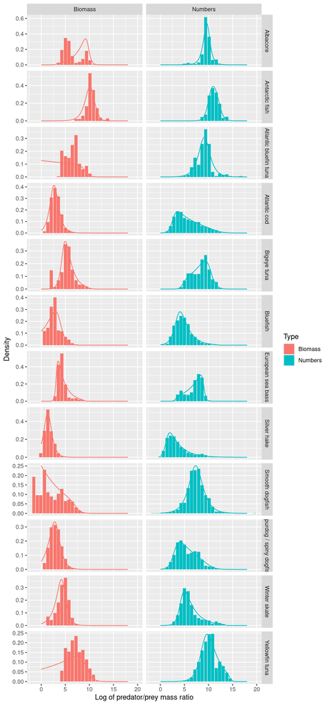

```r
grid = seq(0, 18, length.out = 200)
texpdens <- plyr::ddply(est, "Species", function(df) {
  data.frame(
    l = grid,
    Numbers = dtexp(grid, df$alpha, df$ll, df$ul, df$lr, df$ur),
    Biomass = dtexp(grid, df$alpha - 1, df$ll, df$ul, df$lr, df$ur)
  )}) %>%
  gather(Type, Density, Numbers, Biomass)

ggplot(binned_stomach) +
  geom_col(aes(l, Density, fill = Type)) +
  facet_grid(Species ~ Type, scales = "free_y") +
    xlab("Log of predator/prey mass ratio") +
    geom_line(aes(l, Density, colour = Type), data = texpdens)
```

## Appendix

### More complicated digestion

This still needs work but is probably irrelevant anyway.

As prey items are digested, they loose biomass. Thus the observed size of a prey item will not be the original size at which it was ingested. Let us denote by $S(w)$ the rate at which a prey item of size $w$ looses weight due to digestion. We have already discussed that due to the fact that digestion acts upon the surface of the prey item, we can make the approximation that $S(w)= s w^{2/3}$, with the proportionality constant $S$ depending only on the predator.

The density of observed prey items at a particular size will increase when such a prey item is ingested or if a larger prey item is digested down to this size, and the density will decrease when a prey item is digested down to a smaller size or becomes unidentifiable. This leads to the partial differential equation
$$\frac{N_w(w|w')}{dt} = I(w|w') +\partial_w\left(D(w|w')N_w(w|w')\right)
- U(w|w')N_w(w|w').$$
We assume that on average the stomach observations reflect the steady state with $dN/dt=0$. We now substitute our expressions for the various rates into the resulting balance equation:
$$0 = i(w') \phi(w'/w)\ w^{-\lambda}
+ \frac{\partial}{\partial_w}\left(d(w')w^{2/3}N_w(w|w')\right)
- u(w')w^{-1/3}N_w(w|w')$$